# 一.推荐算法

推荐算法其实是分为许多的,并不仅仅是单一的。如:以下分类

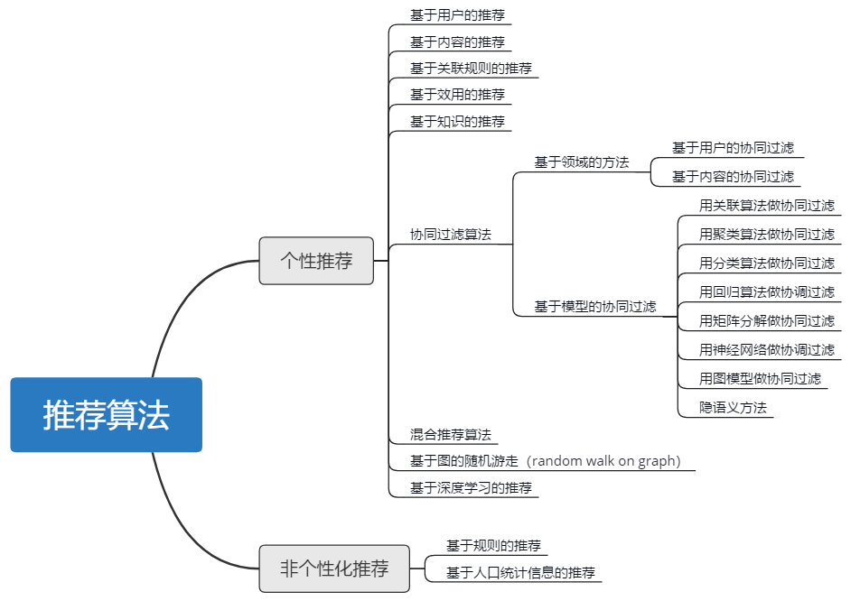

# 二.协同过滤

## 什么是协同过滤,它是怎么工作的？

协同过滤推荐算法是诞生最早，并且较为著名的推荐算法。主要的功能是预测和推荐。算法通过对用户历史行为数据的挖掘发现用户的偏好，基于不同的偏好对用户进行群组划分并推荐品味相似的商品。

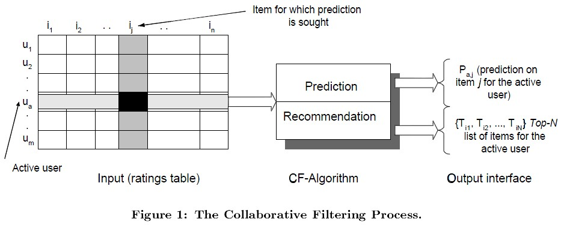

协同过滤(Collaborative Filtering)作为推荐算法中最经典的类型，包括在线的协同和离线的过滤两部分。所谓在线协同，就是通过在线数据找到用户可能喜欢的物品，而离线过滤，则是过滤掉一些不值得推荐的数据，比如推荐值评分低的数据，或者虽然推荐值高但是用户已经购买的数据。

或者可以理解为CF分为两个过程，一个为预测过程，另一个为推荐过程。预测过程是预测用户对没有购买过的物品的可能打分值，推荐是根据预测阶段的结果推荐用户最可能喜欢的一个或Top-N个物品。

协同过滤的模型一般为m个物品，m个用户的数据，在预测过程中只有部分用户和部分数据之间是有评分数据的，其它部分评分是空白，此时我们要用已有的部分稀疏数据来预测那些空白的物品和数据之间的评分关系，找到最高评分的物品推荐给用户。

## 分类

一般来说，协同过滤推荐分为:**基于用户(user-based)的协同过滤**，**基于项目(item-based)的协同过滤**。

- 基于用户(user-based)的协同过滤主要考虑的是用户和用户之间的相似度，只要找出相似用户喜欢的物品，并预测目标用户对对应物品的评分，就可以找到评分最高的若干个物品推荐给用户。
- 基于项目(item-based)的协同过滤和基于用户的协同过滤类似，只不过这时我们转向找到物品和物品之间的相似度，只有找到了目标用户对某些物品的评分，那么我们就可以对相似度高的类似物品进行预测，将评分最高的若干个相似物品推荐给用户。

**用实例理解下基于用户和基于项目的协同过滤:**

1. 对于用户 A，根据用户的历史偏好，这里只计算得到一个邻居 - 用户 C，然后将用户 C 喜欢的物品 D 推荐给用户 A。

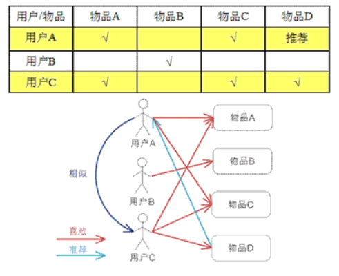

2. 对于物品 A，根据所有用户的历史偏好，喜欢物品 A 的用户都喜欢物品 C，得出物品 A 和物品 C 比较相似，而用户 C 喜欢物品 A，那么可以推断出用户 C 可能也喜欢物品 C。

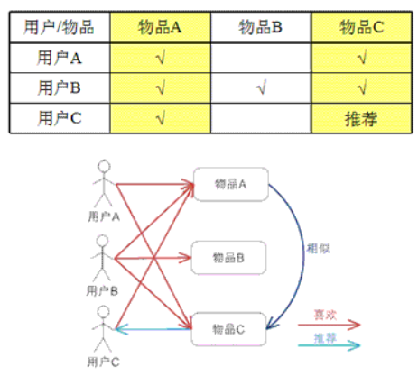

## 比较

简单比较下基于用户的协同过滤和基于项目的协同过滤：

- **基于用户的协同过滤**,需要在线找用户和用户之间的相似度关系，计算复杂度肯定会比基于项目的协同过滤高。但是可以帮助用户找到新类别的有惊喜的物品。
- **基于项目的协同过滤**，由于考虑的物品的相似性一段时间不会改变，因此可以很容易的离线计算，准确度一般也可以接受，但是推荐的多样性来说，就很难带给用户惊喜了。一般对于小型的推荐系统来说，基于项目的协同过滤肯定是主流。但是如果是大型的推荐系统来说，则可以考虑基于用户的协同过滤。

## 算法的步骤

### 收集用户的爱好

要从用户的行为和偏好中发现规律，并基于此给予推荐，如何收集用户的偏好信息成为系统推荐效果最基础的决定因素。用户有很多方式向系统提供自己的偏好信息，而且不同的应用也可能大不相同。

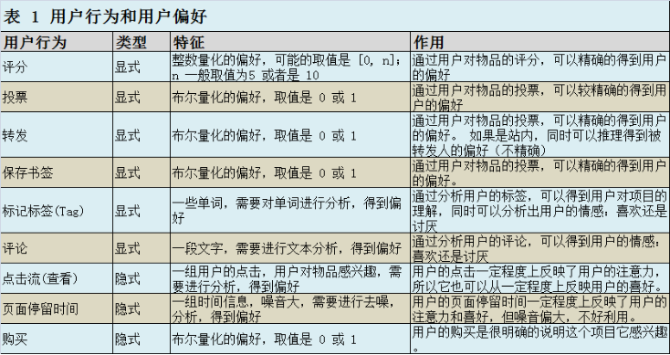

以上列举的用户行为都是比较通用的，推荐引擎设计人员可以根据自己应用的特点添加特殊的用户行为，并用他们表示用户对物品的喜好。在一般应用中，我们提取的用户行为一般都多于一种，关于如何组合这些不同的用户行为，基本上有以下两种方式：

- **将不同的行为分组**：一般可以分为“查看”和“购买”等等，然后基于不同的行为，计算不同的用户 / 物品相似度。类似于当当网或者 Amazon 给出的“购买了该图书的人还购买了 ...”，“查看了图书的人还查看了 ...”。
- **根据不同行为反映用户喜好的程度将它们进行加权，得到用户对于物品的总体喜好**。一般来说，显式的用户反馈比隐式的权值大，但比较稀疏，毕竟进行显示反馈的用户是少数；同时相对于“查看”，“购买”行为反映用户喜好的程度更大，但这也因应用而异。

### 数据减噪和归一化

收集了用户行为数据，我们还需要对数据进行一定的预处理，其中最核心的工作就是：**减噪和归一化**。

- 减噪：用户行为数据是用户在使用应用过程中产生的，它可能存在大量的噪音和用户的误操作，我们可以通过经典的数据挖掘算法过滤掉行为数据中的噪音，这样可以是我们的分析更加精确。
- 归一化：如前面讲到的，在计算用户对物品的喜好程度时，可能需要对不同的行为数据进行加权。但可以想象，不同行为的数据取值可能相差很 大，比如，用户的查看数据必然比购买数据大的多，如何将各个行为的数据统一在一个相同的取值范围中，从而使得加权求和得到的总体喜好更加精确，就需要我们进行归一化处理。最简单的归一化处理，就是将各类数据除以此类中的最大值，以保证归一化后的数据取值在 [0,1] 范围中。

进行的预处理后，根据不同应用的行为分析方法，可以选择**分组**或者**加权处理**，之后我们可以得到一个用户偏好的二维矩阵，一维是用户列表，另一维是物品列表，值是用户对物品的偏好，一般是 [0,1] 或者 [-1, 1] 的浮点数值。

### 找到相似的用户或者物品

当已经对用户行为进行分析得到用户喜好后，我们可以根据用户喜好计算相似用户和物品，然后基于相似用户或者物品进行推荐，这就是最典型的 CF 的两个分支：**基于用户的CF 和 基于物品的CF**。这两种方法都需要计算**相似度**。关于相似度的计算，现有的几种基本方法都是基于向量（Vector）的，其实也就是计算两个向量的距离，距离越近相似度越大。在推荐的场景中，在用户-物品偏好的二维矩阵中，我们可以将一个用户对所有物品的偏好作为一个向量来计算用户之间的相似度，或者将所有用户对某个物品的偏好作为一个向量来计算物品之间的相似度。

#### 相似度计算方法(通用)

**常用的相似度度量公式:**

1. 向量空间余弦相似度(Cosine Similarity)
2. 皮尔森相关系数(Pearson Correlation Coefficient)
3. Jaccard相似系数(Jaccard Coefficient)
4. 调整余弦相似度(Adjusted Cosine Similarity)

**------------------------------------------------------拓展内容-----------------------------------------------------------------**

**在这里我们区分一下常用的距离度量:**

- 距离度量（Distance）用于衡量个体在空间上存在的距离，距离越远说明个体间的差异越大。
- 相似度度量（Similarity），即计算个体间的相似程度，与距离度量相反，相似度度量的值越小，说明个体间相似度越小，差异越大。

**在此列举下距离度量的常用方式**:

1. 欧几里得距离(Euclidean Distance)
2. 明可夫斯基距离(Minkowski Distance)
3. 曼哈顿距离(Manhattan Distance)
4. 切比雪夫距离(Chebyshev Distance)
5. 马哈拉诺比斯距离(Mahalanobis Distance)

**注意:**在实际的应用中距离度量和相似度度量的计算方法都可以用于相似度的计算!!!

#### 相似邻居计算方法(基于用户的CF)

**常用的相似邻居计算方法:**

1. 固定数量的邻居：K-neighborhoods 或者 Fix-size neighborhoods
2. 基于相似度门槛的邻居：Threshold-based neighborhoods

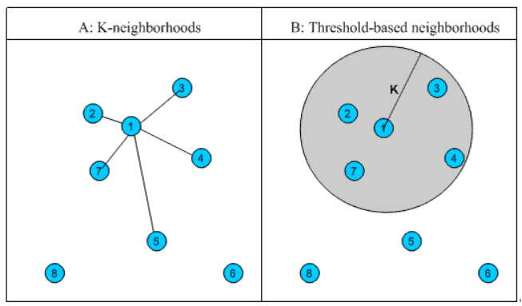

### 推荐

根据用户的喜欢程度(评分)与得到的相似矩阵的计算结果进行排序(选取相似度最高的前k个)推荐。

### 模型评估

**算法性能评估:均方误差(MSE)，均方根误差(RMSE),平均绝对误差(MAE),标准差(SD)**

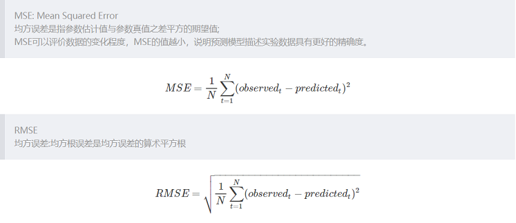

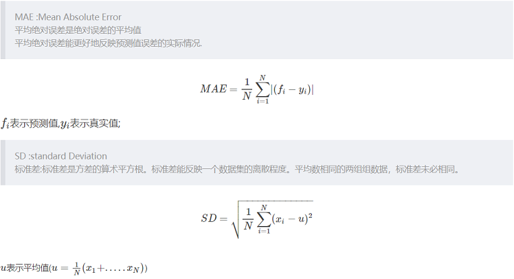

# 三.举例推导

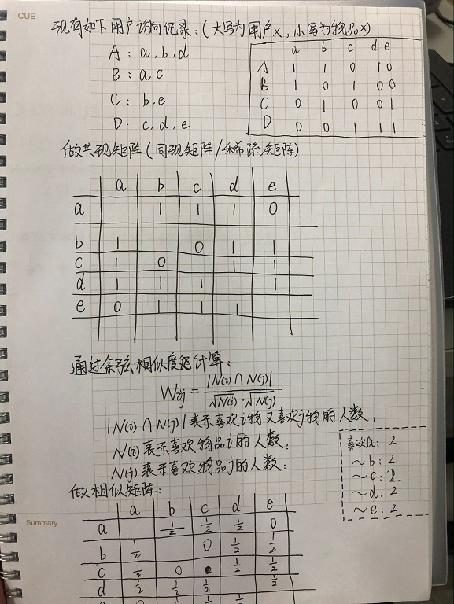

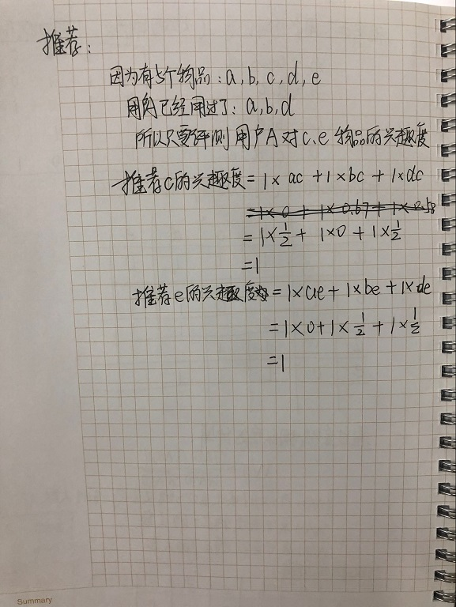

# 四.配套代码

```python
from math import sqrt
import operator
import numpy as np

#1.构建用户-->物品倒排
def LoadData(basis_data):
    data = {}
    for line in basis_data:
        user,score,item = line.split(",")
        data.setdefault(user,{})
        data[user][item] = score
    #print("物品倒排:\n",data)
    return data

#2.构建物品与物品的共(同)现矩阵
def similarity(one_data):
    #构造物品的共现矩阵
    N = {} #喜欢物品i的总人数
    C = {} #喜欢物品i也喜欢物品j的人数
    for user,item in one_data.items():
        for i,score in item.items():
            N.setdefault(i,0)
            N[i] += 1
            C.setdefault(i,{})
            for j,scores in item.items():
                if j not in i:
                    C[i].setdefault(j,0)
                    C[i][j] += 1
    print("喜欢某个物品的人数统计:\n",N)
    print("构造的共现矩阵为:\n",C)
    #计算物品与物品的相似矩阵
    W = {}
    for i,item in C.items():
        W.setdefault(i,{})
        for j,item2 in item.items():
            W[i].setdefault(j,0)
            W[i][j] = C[i][j]/sqrt(N[i]*N[j])
    print("构造的相似矩阵为:\n",W)
    return W

#3.根据用户的历史记录,给用户推荐物品
'''def recommandList(data,W,user,k,N):
    rank={};
    for i,score in data[user].items():#获得用户user历史记录，如A用户的历史记录为{'a': '1', 'b': '1', 'd': '1'}
        for j,w in sorted(W[i].items(),key=operator.itemgetter(1),reverse=True)[0:k]:#获得与物品i相似的k个物品
            if j not in data[user].keys():#该相似的物品不在用户user的记录里
                rank.setdefault(j,0)
                rank[j]+=float(score) * w
    sort_data = sorted(rank.items(),key=operator.itemgetter(1),reverse=True)[0:N]
    print("推荐为:\n",sort_data)
    return sort_data'''

#主函数
if __name__=='__main__':
    #1代表喜欢
    user_item_data = ['A,1,a', 'A,1,b', 'A,1,d', 'B,1,a', 'B,1,c', 'C,1,b', 'C,1,e', 'D,1,c', 'D,1,d', 'D,1,e']
    data  = LoadData(user_item_data)
    W = similarity(data)
    #recommandList(data,W,"A",3,10)
```

```
喜欢某个物品的人数统计:
 {'a': 2, 'b': 2, 'd': 2, 'c': 2, 'e': 2}
构造的共现矩阵为:
 {'a': {'b': 1, 'd': 1, 'c': 1}, 'b': {'a': 1, 'd': 1, 'e': 1}, 'd': {'a': 1, 'b': 1, 'c': 1, 'e': 1}, 'c': {'a': 1, 'd': 1, 'e': 1}, 'e': {'b': 1, 'c': 1, 'd': 1}}
构造的相似矩阵为:
 {'a': {'b': 0.5, 'd': 0.5, 'c': 0.5}, 'b': {'a': 0.5, 'd': 0.5, 'e': 0.5}, 'd': {'a': 0.5, 'b': 0.5, 'c': 0.5, 'e': 0.5}, 'c': {'a': 0.5, 'd': 0.5, 'e': 0.5}, 'e': {'b': 0.5, 'c': 0.5, 'd': 0.5}}
```

```python
data
```

```
{'A': {'a': '1', 'b': '1', 'd': '1'},
 'B': {'a': '1', 'c': '1'},
 'C': {'b': '1', 'e': '1'},
 'D': {'c': '1', 'd': '1', 'e': '1'}}
```

```python
W
```

```
{'a': {'b': 0.5, 'd': 0.5, 'c': 0.5},
 'b': {'a': 0.5, 'd': 0.5, 'e': 0.5},
 'd': {'a': 0.5, 'b': 0.5, 'c': 0.5, 'e': 0.5},
 'c': {'a': 0.5, 'd': 0.5, 'e': 0.5},
 'e': {'b': 0.5, 'c': 0.5, 'd': 0.5}}
```

```python
W["a"]["e"] = 0
W["b"]["c"] = 0
```

```python
#以用户A为例,向他推荐物品
P_Ac = 0
P_Ae = 0
for j in list(data["A"].keys()):
    P_Ac = P_Ac + float(data["A"][j]) * W[j]["c"]
    P_Ae = P_Ae + float(data["A"][j]) * W[j]["e"]
print("用户A对物品c的兴趣度为:",P_Ac,"\n","用户A对物品e的兴趣度为:",P_Ae)
```

```
用户A对物品c的兴趣度为: 1.0
 用户A对物品e的兴趣度为: 1.0
```